# Matrices de rotación en el plano

AL.01 · Transformaciones lineales y geometría

Autor/a

Nikolay Vavilov

Fecha de publicación

4 de octubre de 2026

← Volver al catálogo

**NotaObjetivo**

Deducir la matriz de rotación en $\mathbb{R}^2$, demostrar que preserva norma y ángulos, y comprobarlo numéricamente.

# 1 Planteamiento

Una **rotación** de ángulo $\theta$ alrededor del origen es una transformación lineal $R_\theta:\mathbb{R}^2\to\mathbb{R}^2$. Al ser lineal, queda determinada por lo que hace con la base canónica $\{e_1, e_2\}$.

**Definición 1 (Rotación)** La rotación $R_\theta$ envía $e_1=(1,0)$ a $(\cos\theta,\sin\theta)$ y $e_2=(0,1)$ a $(-\sin\theta,\cos\theta)$.

# 2 Deducción de la matriz

Las columnas de la matriz de una transformación lineal son las imágenes de la base. Por tanto

$$R_\theta =
\begin{pmatrix}
\cos\theta & -\sin\theta \\
\sin\theta & \cos\theta
\end{pmatrix}.
\tag{1}$$

Para un vector $v=(x,y)^\top$ se tiene

$$R_\theta v =
\begin{pmatrix} x\cos\theta - y\sin\theta \\ x\sin\theta + y\cos\theta \end{pmatrix}.
\tag{2}$$

# 3 Propiedades

**Teorema 1 ($R_\theta$ es ortogonal)** Para todo $\theta$, $R_\theta^\top R_\theta = I$ y $\det R_\theta = 1$.

*Demostración*. Al multiplicar,
$$R_\theta^\top R_\theta =
\begin{pmatrix}
\cos^2\theta+\sin^2\theta & 0\\
0 & \sin^2\theta+\cos^2\theta
\end{pmatrix} = I,$$
y $\det R_\theta = \cos^2\theta + \sin^2\theta = 1$.

**Teorema 2 (Preservación de norma y ángulos)** Para todo $u,v\in\mathbb{R}^2$: $\langle R_\theta u, R_\theta v\rangle = \langle u, v\rangle$. En particular $\|R_\theta v\|=\|v\|$ y el ángulo entre $u$ y $v$ no cambia.

*Demostración*. Por el Teorema 1, $\langle R_\theta u, R_\theta v\rangle = u^\top R_\theta^\top R_\theta v = u^\top v$. Tomando $u=v$ se obtiene la igualdad de normas, y como el coseno del ángulo es $\langle u,v\rangle/(\|u\|\|v\|)$, el ángulo se conserva.

**TipComposición**

Rotar $\alpha$ y luego $\beta$ equivale a rotar $\alpha+\beta$, es decir, $R_\beta R_\alpha = R_{\alpha+\beta}$. Esto equivale a las fórmulas del seno y coseno de una suma.

# 4 Verificación numérica

**ver código**

```python
import numpy as np
import matplotlib.pyplot as plt

PAPER, RAISED, INK = "#000000", "#0D1116", "#F2F5F7"
AZUL, MENTA, RULE = "#5cc9ff", "#5dfcef", "#2A3540"

plt.rcParams.update({
    "figure.facecolor": PAPER, "axes.facecolor": RAISED,
    "axes.edgecolor": RULE, "axes.labelcolor": INK,
    "xtick.color": INK, "ytick.color": INK,
    "text.color": INK, "grid.color": RULE,
    "font.family": "monospace",
})

def R(theta):
    c, s = np.cos(theta), np.sin(theta)
    return np.array([[c, -s], [s, c]])
```

Comprobamos con vectores aleatorios que la norma y el producto interno se conservan:

**ver código**

```python
rng = np.random.default_rng(0)
theta = np.pi / 3
U = rng.normal(size=(2, 1000))
V = rng.normal(size=(2, 1000))

err_norma = np.max(np.abs(np.linalg.norm(R(theta) @ U, axis=0)
                          - np.linalg.norm(U, axis=0)))
err_prod = np.max(np.abs(np.sum((R(theta) @ U) * (R(theta) @ V), axis=0)
                         - np.sum(U * V, axis=0)))
err_comp = np.max(np.abs(R(0.7) @ R(0.4) - R(1.1)))

print(f"max |‖Ru‖ - ‖u‖|        = {err_norma:.2e}")
print(f"max |<Ru,Rv> - <u,v>|   = {err_prod:.2e}")
print(f"max |R(0.7)R(0.4)-R(1.1)| = {err_comp:.2e}")
print(f"det R(θ)                = {np.linalg.det(R(theta)):.6f}")
```

```
max |‖Ru‖ - ‖u‖|        = 4.44e-16
max |<Ru,Rv> - <u,v>|   = 1.78e-15
max |R(0.7)R(0.4)-R(1.1)| = 1.67e-16
det R(θ)                = 1.000000
```

Los errores quedan en el orden del error de máquina, como predice el Teorema 2.

# 5 Visualización

**ver código**

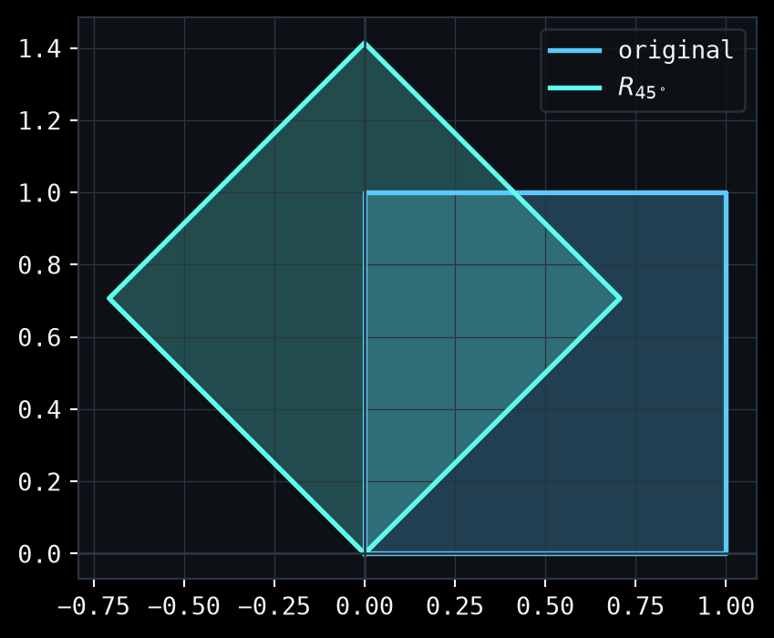

Figura 1: Cuadrado unitario (azul) y su imagen bajo una rotación de 45° (menta).

```python
cuadrado = np.array([[0, 1, 1, 0, 0],
                     [0, 0, 1, 1, 0]], dtype=float)
rotado = R(np.pi / 4) @ cuadrado

fig, ax = plt.subplots(figsize=(5, 5))
ax.fill(*cuadrado, color=AZUL, alpha=0.25)
ax.plot(*cuadrado, color=AZUL, lw=2, label="original")
ax.fill(*rotado, color=MENTA, alpha=0.25)
ax.plot(*rotado, color=MENTA, lw=2, label=r"$R_{45^\circ}$")
ax.axhline(0, color=RULE, lw=1); ax.axvline(0, color=RULE, lw=1)
ax.set_aspect("equal"); ax.grid(True, lw=0.5)
ax.legend(facecolor=RAISED, edgecolor=RULE)
plt.show()
```

La Figura 1 muestra que el cuadrado conserva su forma y tamaño: solo gira.

# 6 Valores propios

Sobre $\mathbb{R}$ una rotación (salvo $\theta=0,\pi$) no tiene vectores propios reales, pero sobre $\mathbb{C}$ sus valores propios son $e^{\pm i\theta}$:

**ver código**

```python
vals = np.linalg.eigvals(R(np.pi / 3))
print("valores propios:", np.round(vals, 6))
print("e^{±iπ/3}      :", np.round([np.exp(1j*np.pi/3), np.exp(-1j*np.pi/3)], 6))
```

```
valores propios: [0.5+0.866025j 0.5-0.866025j]
e^{±iπ/3}      : [0.5+0.866025j 0.5-0.866025j]
```

# 7 Resumen

Tabla 1: Propiedades de la rotación en el plano

| Propiedad | Expresión |
| --- | --- |
| Matriz | $R_\theta=\begin{pmatrix}\cos\theta&-\sin\theta\\ \sin\theta&\cos\theta\end{pmatrix}$ |
| Ortogonalidad | $R_\theta^\top R_\theta = I$ |
| Determinante | $\det R_\theta = 1$ |
| Composición | $R_\beta R_\alpha = R_{\alpha+\beta}$ |
| Valores propios | $e^{\pm i\theta}$ |